[figure not shown]

**Universidade Federal do Rio Grande do Sul**

**Programa de Pós-Graduação em Engenharia Mecânica**

# Lista de exercícios

*Eng. Me. Daniel B. M. Matos*

*Prof. Daniel M. Leon*

## Introdução

Neste trabalho, é utilizada a linguagem Python, aliada à ferramenta `Jupyter Notebook` para a realização dos exercícios propostos na disciplina MEC00091 - Introdução à otimização estrutural.

## Exemplo dado em sala de aula

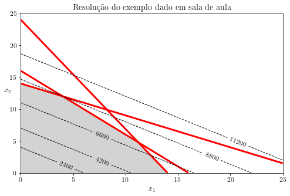

## Problema 3.1

\begin{align*} \mbox{Minimizar}\ f(x_1,x_2) &= (x_1-3)^2 +(x_2-3)^2 \\ \mbox{suj. a}\ x_1 + x_2 &\le 4 \\ x_1,x_2 &\ge 0 \end{align*}

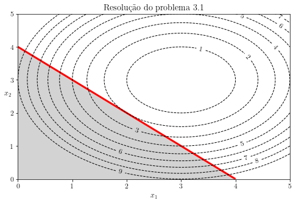

o mínimo da função é 2, com variáveis de projeto iguais a $\vec{x} = [2\ 2]^T $

## Problema 3.2

\begin{align*} \mbox{Maximizar}\ F(x_1,x_2) &= x_1 + 2x_2\\ \mbox{suj. a}\ 2x_1 + x_2 &\le 4 \\ x_1,x_2 &\ge 0 \end{align*}

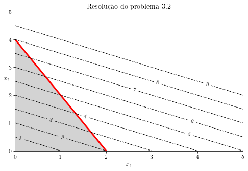

o máximo da função é 8, com variáveis de projeto iguais a $\vec{x} = [0\ 4]^T $

## Problema 3.3

\begin{align*} \mbox{Minimizar}\ f(x_1,x_2) &= x_1 + 3x_2\\ \mbox{suj. a}\ x_1 + 4x_2 &\le 48 \\ 5x_1 + x_2 &\ge 50 \\ x_1,x_2 &\ge 0 \end{align*}

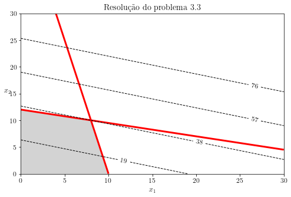

## Problema 3.4

\begin{align*} \mbox{Maximizar}\ F(x_1,x_2) &= x_1 + x_2 + 2x_3\\ \mbox{suj. a}\ 1 \le x_1 &\le 4 \\ 3x_2-2x_3 &= 6 \\ -1 &\le x_1 \le 2 \\ x_2 &\ge 0 \end{align*}

Para resolver o problema, deve-se excluir a variável $x_3$ do problema, a partir da restrição de igualdade:

\begin{align*} \mbox{Maximizar}\ F(x_1,x_2) &= -x_1 - 4x_2 + 6\\ \mbox{suj. a}\ 1 \le x_1 &\le 4 \\ 4/3 \le x_2 &\ge 10/3 \end{align*}

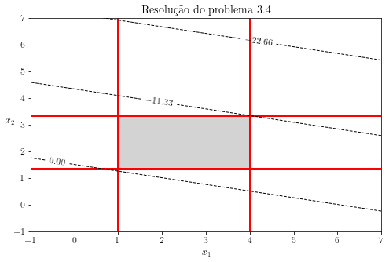

## Problema 3.5

\begin{align*} \mbox{Maximizar}\ F(x_1,x_2) &= 4x_1x_2\\ \mbox{suj. a}\ x_1 + x_2 &\le 20 \\ x_2-x_1 &\le 10 \\ x_1,x_2 &\ge 0 \end{align*}

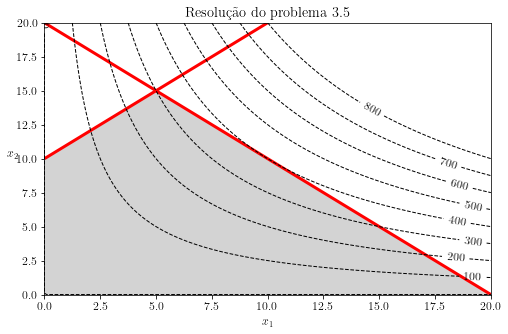

o máximo da função é 400, com variáveis de projeto iguais a $\vec{x} = [10\ 10]^T $

## Problema 3.23

For the minimum mass tubular column design problem formulated in Section 2.7, consider the following data: P = 50 kN; l = 5.0 m; modulus of elasticity, E= 210 GPa; allowable stress, σa= 250 MPa; mass density, 𝜌 = 7850 kg/m3.

Treating mean radius R and wall thickness t as design variables, solve the design problem graphically imposing an additional constraint R/t ≤ 50. This constraint is needed to avoid local crippling of the column. Also impose the member size constraints as

\begin{align*} 0.01 &\le R \le 1 m\\ 5 &\le t \le 200 mm \end{align*}

De acordo com o observado no problema 2.7, pode-se montar o problema de otimização:

\begin{align*} \mbox{Minimizar}\ F(R,t) &= 2\rho l \pi Rt\\ \mbox{suj. a}\ \frac{P}{2\pi R t} - \sigma_a &\le 0 \\ P - \frac{\pi^3ER^3t}{4l^2} &\le 0 \\ \frac{R}{t} - 50 &\le 0 \\ R_{min} - R &\le 0 \\ R - R_{max}&\le 0 \\ t_{min} - t &\le 0 \\ t - t_{max} -&\le 0 \\ \end{align*}

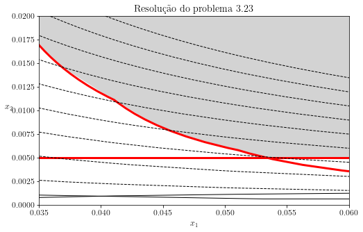

## Problema 3.24

For Exercise 3.23, treat outer radius 𝑅0 and inner radius 𝑅𝑖 as design variables, and solve the design problem graphically. Impose the same constraints as in Exercise 3.23.

\begin{align*} \mbox{Minimizar}\ F(R,t) &= \rho l \pi (R_0^2 - R_i^2)\\ \mbox{suj. a}\ \frac{P}{(R_0^2 - R_i^2)} - \sigma_a &\le 0 \\ P - \frac{\pi^3E(R_0^4 - R_i^4)}{16l^2} &\le 0 \\ \frac{(R_0 + R_i)}{2(R_0 - R_i)} - 50 &\le 0 \\ R_{min} - R &\le 0 \\ R - R_{max}&\le 0 \\ t_{min} - (R_0 - R_i) &\le 0 \\ (R_0 - R_i) - t_{max} -&\le 0 \\ \end{align*}

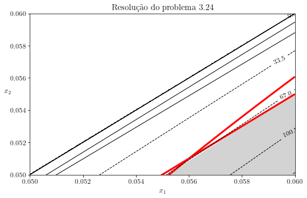

o mínimo da função é 66 kg, com variáveis de projeto iguais a $\vec{x} = [56\ 51]^T mm.$ As funções $g_2(x)$ e $g_6(x)$ são as restrições ativas do problema.

## Problema 3.25

Formulate the minimum mass column design problem of Section 2.7 using a hollow square cross section with outside dimension w and thickness t as design variables. Solve the problem graphically using the constraints and the data given in Exercise 3.23.

Escrevem-se as funções de área e inércia da seção quadrada vazada por meio das equações: \begin{align*} A &= 4at - 4t^2 \\ I &= \frac{a^4-(a-2t)^2}{12} \end{align*}

O restante da solução é idêntica às soluções dos problemas 3.24 e 3.23, podendo-se escrever o problema de minimização como:

\begin{align*} \mbox{Minimizar}\ F(a,t) &= 2\rho l (4at - 4t^2)\\ \mbox{suj. a}\ \frac{P}{4at - 4t^2} - \sigma_a &\le 0 \\ P - \frac{\pi^3E(a^4-(a-2t)^2)}{48l^2} &\le 0 \\ \frac{a}{t} - 151 &\le 0 \\ R_{min} - \frac{a}{t} &\le 0 \\ \frac{a}{t} - R_{max}&\le 0 \\ t_{min} - t &\le 0 \\ t - t_{max} -&\le 0 \\ \end{align*}

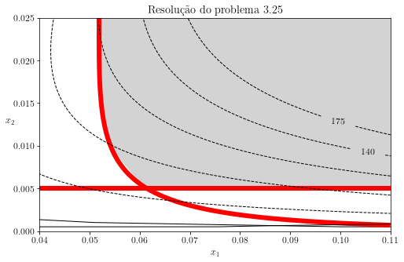

## Problema 3.28

In the design of a closed-end, thin-walled cylindrical pressure vessel shown in Fig. E3.28, the design objective is to select the mean radius R and wall thickness t to minimize the total mass. The vessel should contain at least 25.0 m3 of gas at an internal pressure of 3.5 MPa. It is required that the circumferential stress in the pressure vessel not exceed 210 MPa and the circumferential strain not exceed (1.0E-03). The circumferential stress and strain are calculated from the equations: \begin{align*} \sigma_c &= \frac{PR}{t} \\ \epsilon_c &= \frac{PR(2-\nu}{2Et} \end{align*}

O restante da solução é idêntica às soluções dos problemas 3.24 e 3.23, podendo-se escrever o problema de minimização como:

\begin{align*} \mbox{Minimizar}\ F(a,t) &= 2\pi \rho l Rt\\ \mbox{suj. a}\ 25 - \pi(R-t/2)^2l &\le 0\\ \frac{PR}{t} - \sigma_a &\le 0 \\ \frac{PR(2-\nu)}{2Et} - \epsilon_c &\le 0 \\ -R + 0.5t &\le 0 \\ -R &\le 0 \\ -t &\le 0 \\ \end{align*}

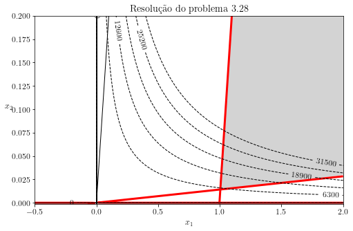

o mínimo da função é 6300 kg, com variáveis de projeto iguais a $\vec{x} = [1\ 0.0168]^T m.$ As funções $g_1(x)$ e $g_2(x)$ são as restrições ativas do problema.

## Problema 3.29

Consider the symmetric three-bar truss design problem formulated in Section 2.10. Formulate and solve the problem graphically for the following data:l = 1.0 m; P = 100 kN; 𝜃 = 30°; mass density, 𝜌 = 2800 kg/m3; modulus of elasticity, E = 70 GPa; allowable stress, 𝜎𝑎 = 140 MPa; ∆u = 0.5 cm; ∆v = 0.5 cm; 𝜔𝑜 = 50 Hz; 𝛽𝛽 = 1.0; A1, A2 ≥ 2 cm2.

A formulação do problema está descrita em 2.10:

\begin{align*} \mbox{Minimizar}\ F(A_1,A_2) &= \rho l (2\sqrt{2}A_1+A_2)\\ \mbox{suj. a}\ \frac{\frac{P\cos\theta}{A_1}+\frac{P\sin\theta}{A_1+\sqrt2 A_2}}{\sqrt2} - \sigma_a &\le 0\\ \frac{\sqrt2 P \sin\theta}{A_1 +\sqrt2A_2} - \sigma_a &\le 0\\ \frac{\sqrt2 Pl \cos\theta}{A_1 E} - \Delta_u &\le 0\\ \frac{\sqrt2 Pl \sin\theta}{A_1 +\sqrt2A_2} - \sigma_a &\le 0\\ (2\pi \omega_0)^2-\frac{3EA_1}{\rho l^2 (4A_1+ \sqrt2A_2)}&\le 0 \\ -\frac{\frac{P\sin\theta}{A_1 +\sqrt2A_2} - \frac{P\cos\theta}{A_1}}{\sqrt2} - \frac{\pi^2E\beta A_1}{2l^2} &\le 0\\ 2-A_1 &\le 0 \\ 2-A_2 &\le 0 \\ \end{align*}

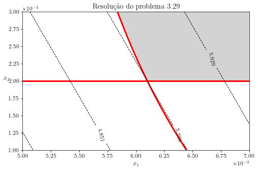

O mínimo da função é 5.39 kg, com variáveis de projeto iguais a $\vec{x} = [6.1\ 2]^T cm^2.$ As funções $g_1(x)$ e $g_8(x)$ são as restrições ativas do problema.

## Problema 3.33

Consider the minimum mass tubular column problem formulated in Section 2.7. Find the optimum solution for the problem using the graphical method for the data:load, P = 100 kN; length, l = 5.0 m; Young’s modulus, E = 210GPa; allowable stress, 𝜎𝑎 = 250MPa; mass density, 𝜌 =7850 kg/m3, R ≤ 0.4 m; t ≤ 0.1 m; R, t ≥ 0.

A montagem do problema é idêntica à realizada no problema 3.23, alterando-se apenas os dados do problema.

\begin{align*} \mbox{Minimizar}\ F(R,t) &= 2\rho l \pi Rt\\ \mbox{suj. a}\ \frac{P}{2\pi R t} - \sigma_a &\le 0 \\ P - \frac{\pi^3ER^3t}{4l^2} &\le 0 \\ R_{min} - R &\le 0 \\ R - R_{max}&\le 0 \\ t_{min} - t &\le 0 \\ t - t_{max} -&\le 0 \\ \end{align*}

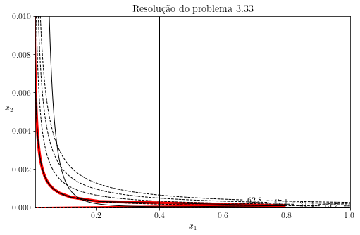

O valor ótimo da função é de 15.7 kg, e a função g1(x) coincide com a função objetivo, portanto g1(x) é a única restrição ativa e existem múltiplos pontos que satisfazem o problema.

## Problema 3.34

Design a hollow torsion rod shown in Fig.E3.34 to satisfy the following requirements (created by J.M. Trummel):

1. The calculated shear stress, 𝜏, shall not exceed the allowable shear stress 𝜏𝜏𝑎𝑎under the normal operation torque To (N·m).
2. The calculated angle of twist, 𝜃, shall not exceed the allowable twist, 𝜃𝑎 (radians).
3. The member shall not buckle under a short duration torque of Tmax (N·m).

Requirements for the rod and material properties are given in Table E3.34(A) and E3.34(B) (select a material for one rod). Use the following design variables: x1 = outside diameter of the shaft; x2 = ratio of inside/outside diameter, di/do.Using graphical optimization, determine the inside and outside diameters for a minimum mass rod to meet the above design requirements. Compare the hollow rod with an equivalent solid rod (di /do = 0). Use consistent set of units (e.g. Newtons and millimeters) and let the minimum and maximum values for design variables be given as

\begin{align*} 0.02 \le d_o \le 0.5 m, \ \ 0.60 \le \frac{d_i}{d_o} \le 0.9999 \end{align*}

Usando a Tabela E3.34(d), formula-se o problema de otimização:

Definindo $\gamma$ como $d_i/d_o$.

\begin{align*} \mbox{Minimizar}\ F(d_o,\gamma) &= \frac{\pi\rho l}{4}d_o(1-\gamma^2)\\ \mbox{suj. a}\ \frac{T_o 0.5d_o}{\pi d_o^4(1-\gamma)/32} - \tau_a &\le 0 \\ \frac{\dfrac{32 T_o l}{G \pi}}{d_o^4(1-\gamma^2)} - \theta_a &\le 0 \\ -\frac{\pi E d_o^3(1-\gamma)^{2.5}}{12\sqrt2(1-\nu^2)^{0.75}} + T_{max} &\le 0 \\ \end{align*}

Utilizam-se os valores da vara de número 1 (Tabela 3.34 A) e do material de número 1 (Tabela 3.34 B).

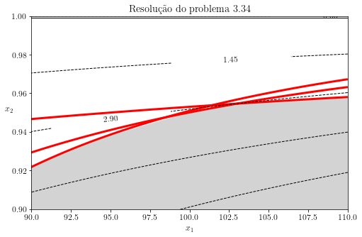

O mínimo da função é 2.9 kg, com variáveis de projeto iguais a $\vec{x} = [103\ 0.955]^T mm.$ As funções $g_1(x)$, $g_2(x)$ e $g_3(x)$ são as restrições ativas do problema.

## Problema 3.52

Design of a flag pole. Your consulting firm has been design a minimum mass flag pole of height H. The pole will be made of uniform hollow circular tubing with do and di as outer and inner diameters, respectively. The pole must not fail under the action of high winds.

For design purpose, the pole will be treated as a cantilever that is subjected to a uniform lateral wind load of w (kN/m). In addition to the uniform load, the wind introduces a concentrated load P (kN) at the top of the pole, as shown in Fig. E3.52. The flag pole must not fail in bending or shear. The deflection at the top should not exceed 10 cm. The ratio of mean diameter to thickness must not exceed 60. The pertinent data are given below. Assume any other data if needed. The minimum and maximum values of design variables are 5 ≤ do ≤ 50 cm and 4 ≤ di ≤ 45 cm.

Para a solução do problema, escrevem-se as seguintes equações com base nas variáveis de projeto.

\begin{align*} A &= \frac{\pi(d_o^2-d_i^2)}{4}\\ I &= \frac{\pi(d_o^4-d_i^4)}{64} \end{align*}

Os esforços externos aplicados na base da estrutura são: \begin{align*} V &= P + wH\\ M &= PH + \frac{wH^2}{2} \end{align*}

A formulação do problema pode ser escrita como:

\begin{align*} \mbox{Minimizar}\ F(d_o,d_i) &= \frac{\pi\rho H(d_o^2-d_i^2)}{4}\\ \mbox{suj. a}\ \frac{Md_o}{2I} - \sigma_a &\le 0\\ \frac{V (d_o^2+d_od_i+d_i^2)}{12 I} - \tau_a &\le 0\\ \frac{PH^3}{3EI} + \frac{wH^4}{8EI} - \delta &\le 0\\ \frac{d_o + d_i}{d_o-d_i} - 60&\le 0\\ \frac{d_o - d_i}{2} - 2&\le 0 \\ 0.5 - \frac{d_o -d_i}{2} &\le 0\\ d_o - 50 &\le 0 \\ 5 - d_o &\le 0 \\ d_i - 45 &\le 0 \\ 4 - d_i &\le 0 \\ \end{align*}

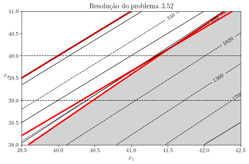

O mínimo da função é 680 kg, com variáveis de projeto iguais a $\vec{x} = [41.56\ 40.19]^T cm.$ As funções $g_3(x)$ e $g_4(x)$ são as restrições ativas do problema.

## Problema 4.22

\begin{align} f(x_1,x_2) = 3x_1^2 +2x_1x_2 + 2x_2^2 +7 \end{align}

Primeiramente, calcula-se o gradiente da função.

$\displaystyle \nabla f(x) = \left[\begin{matrix}6 x_{1} + 2 x_{2}\\2 x_{1} + 4 x_{2}\end{matrix}\right]$

Igualando os termos do gradiente a zero, obtemos as condições necessárias do problema.

$\displaystyle x^* = \left[\begin{matrix}0 & 0\end{matrix}\right]$

A Hessiana da função no ponto de projeto pode ser escrita por:

$\displaystyle H = \left[\begin{matrix}6 & 2\\2 & 4\end{matrix}\right]$

E os seus autovalores são dados por:

$\displaystyle \lambda = \left\{ 5 - \sqrt{5} : 1, \ \sqrt{5} + 5 : 1\right\}$

$\displaystyle \left\{ x_{1} : 0, \ x_{2} : 0\right\}$

## Problema 4.23

\begin{align} f(x_1,x_2) = x_1^2 +4x_1x_2 + x_2^2 + 3 \end{align}

Primeiramente, calcula-se o gradiente da função.

$\displaystyle \nabla f(x) = \left[\begin{matrix}2 x_{1} + 4 x_{2}\\4 x_{1} + 2 x_{2}\end{matrix}\right]$

Igualando os termos do gradiente a zero, obtemos as condições necessárias do problema.

$\displaystyle x^* = \left[\begin{matrix}0 & 0\end{matrix}\right]$

A Hessiana da função no ponto de projeto pode ser escrita por:

$\displaystyle H = \left[\begin{matrix}2 & 4\\4 & 2\end{matrix}\right]$

## Problema 4.24

\begin{align} f(x_1,x_2) = x_1^3 +12x_1x_2^2 + 2x_2^2 + 5x_1^2 + 3x_2 \end{align}

Primeiramente, calcula-se o gradiente da função.

$\displaystyle \nabla f(x) = \left[\begin{matrix}3 x_{1}^{2} + 10 x_{1} + 12 x_{2}^{2}\\24 x_{1} x_{2} + 4 x_{2} + 3\end{matrix}\right]$

Igualando os termos do gradiente a zero, obtemos as condições necessárias do problema.

$\displaystyle x^*_1 = \left[\begin{matrix}-3.332 & 0.0395\end{matrix}\right]$

$\displaystyle x^*_2 = \left[\begin{matrix}-0.398 & 0.5404\end{matrix}\right]$

A Hessiana da função no ponto de projeto pode ser escrita por:

$\displaystyle H_1 = \left[\begin{matrix}-9.992 & 0.948\\0.948 & -75.968\end{matrix}\right]$

$\displaystyle H_2 = \left[\begin{matrix}7.612 & 12.9696\\12.9696 & -5.552\end{matrix}\right]$

E os seus autovalores são dados por:

$\displaystyle \lambda_1 = \left\{ -75.9816188693827 : 1, \ -9.97838113061724 : 1\right\}$

$\displaystyle \lambda_2 = \left\{ -13.5141826226158 : 1, \ 15.5741826226158 : 1\right\}$

Aplicando os pontos que atendem às condições necessárias, obtém-se que $x^*_1$ é um máximo local, visto que a matriz hessiana é negativa definida, enquanto $x^*_2$ é um ponto de inflexão, já que a matriz é indefinida.

## Problema 4.25

\begin{align} f(x_1,x_2) = 5x_1 -\frac{x_1^2x_2}{16} + \frac{x_2^2}{4x_1} \end{align}

Primeiramente, calcula-se o gradiente da função.

$\displaystyle \nabla f(x) = \left[\begin{matrix}- \frac{x_{1} x_{2}}{8} + 5 - \frac{x_{2}^{2}}{4 x_{1}^{2}}\\- \frac{x_{1}^{2}}{16} + \frac{x_{2}}{2 x_{1}}\end{matrix}\right]$

Igualando os termos do gradiente a zero, obtemos as condições necessárias do problema.

$\displaystyle x^*_1 = \left[\begin{matrix}-4 & -8\end{matrix}\right]$

$\displaystyle x^*_2 = \left[\begin{matrix}4 & 8\end{matrix}\right]$

Além dos valores encontrados acima, números complexos conjugados também foram encontrados. Porém, para dar continuidade ao problema de otimização, utilizam-se apenas os valores reais.

A Hessiana da função no ponto de projeto pode ser escrita por:

$\displaystyle H_1 = \left[\begin{matrix}- \frac{3}{2} & \frac{1}{4}\\\frac{1}{4} & - \frac{1}{8}\end{matrix}\right]$

$\displaystyle H_2 = \left[\begin{matrix}- \frac{1}{2} & - \frac{3}{4}\\- \frac{3}{4} & \frac{1}{8}\end{matrix}\right]$

E os seus autovalores são dados por:

$\displaystyle \lambda_1 = \left\{ - \frac{13}{16} - \frac{\sqrt{137}}{16} : 1, \ - \frac{13}{16} + \frac{\sqrt{137}}{16} : 1\right\}$

$\displaystyle \lambda_2 = \left\{ -1 : 1, \ \frac{5}{8} : 1\right\}$

## Problema 4.26

\begin{align} f(x) = \cos{x} \end{align}

Primeiramente, calcula-se o gradiente da função.

$\displaystyle \nabla f(x) = - \sin{\left(x \right)}$

Igualando o gradiente a zero, obtemos as condições necessárias do problema: $x =n\pi$ com n = 0,1,2,3,4,...,n. A derivada segunda da função pode ser escrita por:

$\displaystyle f(x) = - \cos{\left(x \right)}$

Portanto, quando n for ímpar, x será um ponto de mínimo e, quando n for par, x será um ponto de máximo.

## Problema 4.32

The annual operating cost U for an electrical line system is given by the following expression

\begin{align} U = \frac{21.9E7}{V^2C} + 3.9E6C + 1000V \end{align}

where V = line voltage in kilovolts and C = line conductance in mhos. Find stationary points for the function, and determine V and C to minimize the operating cost.

Primeiramente, calcula-se o gradiente da função. Define-se V como $x_1$ e C como $x_2$.

$\displaystyle \nabla f(x) = \left[\begin{matrix}1000 - \frac{438000000.0}{x_{1}^{3} x_{2}}\\3900000.0 - \frac{219000000.0}{x_{1}^{2} x_{2}^{2}}\end{matrix}\right]$

Igualando os termos do gradiente a zero, obtemos as condições necessárias do problema.

$\displaystyle x^*_1 = \left[\begin{matrix}-241.764 & -0.0031\end{matrix}\right]$

$\displaystyle x^*_2 = \left[\begin{matrix}241.764 & 0.0031\end{matrix}\right]$

Além dos valores encontrados acima, números complexos conjugados também foram encontrados. Porém, para dar continuidade ao problema de otimização, utilizam-se apenas os valores reais.

A Hessiana da função no ponto de projeto pode ser escrita por:

$\displaystyle H_1 = \left[\begin{matrix}-124.070102625535 & -3225342.39689891\\-3225342.39689891 & -251539251368.99\end{matrix}\right]$

$\displaystyle H_2 = \left[\begin{matrix}124.070102625535 & 3225342.39689891\\3225342.39689891 & 251539251368.99\end{matrix}\right]$

E os seus autovalores são dados por:

$\displaystyle \lambda_1 = \left\{ -251539251410.346 : 1, \ -82.7134017367573 : 1\right\}$

$\displaystyle \lambda_2 = \left\{ 82.7134017367573 : 1, \ 251539251410.346 : 1\right\}$

A partir dos autovalores, percebe-se que o ponto 1 é um ponto de máximo, visto que a matriz é negativo definida, enquanto o ponto 2 é um ponto de mínimo, já que a matriz é positivo definida.

## Problema 4.43

\begin{align*} \mbox{Minimizar}\ f(x_1,x_2) &= 4x_1^2 + 3x_2^2-5x_1x_2-8x_1\\ \mbox{suj. a}\ x_1+x_2 &= 4\\ \end{align*}

Primeiramente, é necessário definir o lagrangeano da função e minimizar o mesmo. \begin{align*} \mbox{Minimizar}\ L(x_1,x_2,\nu) &= 4x_1^2 + 3x_2^2-5x_1x_2-8x_1 + \nu (x_1+x_2-4)\\ \end{align*}

Agora, calcula-se o gradiente da função.

$\displaystyle \nabla f(x) = \left[\begin{matrix}\nu + 8 x_{1} - 5 x_{2} - 8\\\nu - 5 x_{1} + 6 x_{2}\\x_{1} + x_{2} - 4\end{matrix}\right]$

Igualando os termos do gradiente a zero, obtemos as condições necessárias do problema.

$\displaystyle \left\{ \nu : - \frac{1}{6}, \ x_{1} : \frac{13}{6}, \ x_{2} : \frac{11}{6}\right\}$

## Problema 4.45

\begin{align*} \mbox{Minimizar}\ f(x_1,x_2) &= (x_1-2)^2 + (x_2+1)^2\\ \mbox{suj. a}\ 2x_1+3x_2 &= 4\\ \end{align*}

Primeiramente, é necessário definir o lagrangeano da função e minimizar o mesmo. \begin{align*} \mbox{Minimizar}\ L(x_1,x_2,\nu) &= (x_1-2)^2 + (x_2+1)^2 + \nu (2x_1+3x_2-4)\\ \end{align*}

Agora, calcula-se o gradiente da função.

$\displaystyle \nabla f(x) = \left[\begin{matrix}2 \nu + 2 x_{1} - 4\\3 \nu + 2 x_{2} + 2\\2 x_{1} + 3 x_{2} - 4\end{matrix}\right]$

Igualando os termos do gradiente a zero, obtemos as condições necessárias do problema.

$\displaystyle \left\{ \nu : - \frac{6}{13}, \ x_{1} : \frac{32}{13}, \ x_{2} : - \frac{4}{13}\right\}$

## Problema 4.47

\begin{align*} \mbox{Minimizar}\ f(x_1,x_2,x_3) &= (x_1-1)^2 + (x_2+2)^2 + (x_3-2)^2\\ \mbox{suj. a}\ 2x_1+3x_2 &= 1\\ x_1+x_2+2x_3 &= 4 \end{align*}

Primeiramente, é necessário definir o lagrangeano da função e minimizar o mesmo. \begin{align*} \mbox{Minimizar}\ L(x_1,x_2,\nu_1,\nu_2) &= (x_1-1)^2 + (x_2+2)^2 + (x_3-2)^2 + \nu_1 (2x_1+3x_2-1) + \nu_2 (x_1+x_2+2x_3-4)\\ \end{align*}

Agora, calcula-se o gradiente da função.

$\displaystyle \nabla f(x) = \left[\begin{matrix}2 \nu_{1} + \nu_{2} + 2 x_{1} - 2\\3 \nu_{1} + \nu_{2} + 2 x_{2} + 4\\2 \nu_{2} + 2 x_{3} - 4\\2 x_{1} + 3 x_{2} - 1\\x_{1} + x_{2} + 2 x_{3} - 4\end{matrix}\right]$

Igualando os termos do gradiente a zero, obtemos as condições necessárias do problema.

$\displaystyle \left\{ \nu_{1} : - \frac{50}{53}, \ \nu_{2} : \frac{24}{53}, \ x_{1} : \frac{91}{53}, \ x_{2} : - \frac{43}{53}, \ x_{3} : \frac{82}{53}\right\}$

## Problema 4.54

\begin{align*} \mbox{Maximizar}\ f(x_1,x_2) &= 4x_1^2 +3x_2^2-5x_1x_2 -8\\ \mbox{suj. a}\ x_1 +x_2 \le 4\\ \end{align*}

A príncipio, transforma-se o problema para minimização.

\begin{align*} \mbox{Minimizar}\ f(x_1,x_2) &= -4x_1^2 -3x_2^2+5x_1x_2 +8\\ \mbox{suj. a}\ x_1 +x_2 \le 4\\ \end{align*}

Agora, é necessário definir o lagrangeano da função e minimizar o mesmo. \begin{align*} \mbox{Minimizar}\ L(x_1,x_2,\nu,s) &= -4x_1^2 -3x_2^2 +5x_1x_2 + 8 + \nu (x_1+x_2-4 + s^2)\\ \end{align*}

Agora, calcula-se o gradiente da função.

$\displaystyle \nabla f(x) = \left[\begin{matrix}\nu_{} - 8 x_{1} + 5 x_{2}\\\nu_{} + 5 x_{1} - 6 x_{2}\\s^{2} + x_{1} + x_{2} - 4\\2 \nu_{} s\end{matrix}\right]$

Igualando os termos do gradiente a zero, obtemos as condições necessárias do problema.

$\displaystyle \left( \left[ s, \ x_{1}, \ x_{2}\right], \ \left\{\left( 2, \ 0, \ 0\right)\right\}\right)$

$\displaystyle \left\{ \nu_{} : \frac{23}{6}, \ x_{1} : \frac{11}{6}, \ x_{2} : \frac{13}{6}\right\}$

Portanto, é possível definir dois pontos de KKT.

## Problema 4.55

\begin{align*} \mbox{Minimizar}\ f(x_1,x_2) &= 4x_1^2 +3x_2^2-5x_1x_2 -8\\ \mbox{suj. a}\ x_1 +x_2 \le 4\\ \end{align*}

A princípio, é necessário definir o lagrangeano da função e minimizar o mesmo.

\begin{align*} \mbox{Minimizar}\ L(x_1,x_2,\nu,s) &= 4x_1^2 + 3x_2^2 - 5x_1x_2 - 8 + \nu (x_1+x_2 - 4 + s^2)\\ \end{align*}

Agora, calcula-se o gradiente da função.

$\displaystyle \nabla f(x) = \left[\begin{matrix}\nu_{} + 8 x_{1} - 5 x_{2}\\\nu_{} - 5 x_{1} + 6 x_{2}\\s^{2} + x_{1} + x_{2} - 4\\2 \nu_{} s\end{matrix}\right]$

Igualando os termos do gradiente a zero, obtemos as condições necessárias do problema.

$\displaystyle \left( \left[ s, \ x_{1}, \ x_{2}\right], \ \left\{\left( 2, \ 0, \ 0\right)\right\}\right)$

$\displaystyle \left\{ \nu_{} : - \frac{23}{6}, \ x_{1} : \frac{11}{6}, \ x_{2} : \frac{13}{6}\right\}$

Nesse caso, apenas o ponto (0,0) satisfaz o problema, visto que $\nu >0$

## Problema 4.67

\begin{align*} \mbox{Minimizar}\ f(x_1,x_2) &= (x_1-1)^2 + (x_2-1)^2\\ \mbox{suj. a}\ x_1 +x_2 \le 4\\ 2 - x_1 \le 0\\ \end{align*}

A princípio, é necessário definir o lagrangeano da função e minimizar o mesmo.

\begin{align*} \mbox{Minimizar}\ L(x_1,x_2,\nu_1,s_1,\nu_2,s_2) &= (x_1-1)^2 + (x_2-1)^2 + \nu_1 (x_1+x_2 - 4 + s_1^2) + \nu_2 (2-x_1 + s_2^2)\\ \end{align*}

Agora, calcula-se o gradiente da função.

$\displaystyle \nabla f(x) = \left[\begin{matrix}\nu_{1} - \nu_{2} + 2 x_{1} - 2\\\nu_{1} + 2 x_{2} - 2\\s_{1}^{2} + x_{1} + x_{2} - 4\\2 \nu_{1} s_{1}\\s_{2}^{2} - x_{1} + 2\\2 \nu_{2} s_{2}\end{matrix}\right]$

Igualando os termos do gradiente a zero, obtemos as condições necessárias do problema.

$\displaystyle \left( \left[ \right], \ \left\{\right\}\right)$

$\displaystyle \left( \left[ \nu_{2}, \ s_{1}, \ x_{1}, \ x_{2}\right], \ \left\{\left( 2, \ 1, \ 2, \ 1\right)\right\}\right)$

$\displaystyle \left( \left[ \right], \ \left\{\right\}\right)$

$\displaystyle \left( \left[ \nu_{1}, \ \nu_{2}, \ x_{1}, \ x_{2}\right], \ \left\{\left( -2, \ 0, \ 2, \ 2\right)\right\}\right)$

Percebe-se que a única solução que atende aos critérios de KKT é (2,1).

## Problema 4.75

\begin{align*} \mbox{Maximizar}\ f(x_1,x_2) &= (x_1-8)^2 + (x_2-8)^2\\ \mbox{suj. a}\ x_1 + x_2 - 10 &\le 0\\ x_2-5 &\le 0\\ -x_1 &\le 0\\ -x_2 &\le 0\\ \end{align*}

A princípio, é necessário definir o lagrangeano da função e minimizar o mesmo.

\begin{align*} \mbox{Minimizar}\ L &= -(x_1-8)^2 - (x_2-1)^2 + \nu_1 (x_1+x_2 - 10 + s_1^2) + \nu_2 (x_2 -5 + s_2^2) + \nu_3 (-x_1 + s_3^2) + \nu_4 (-x_2 + s_4^2)\\ \end{align*}

Agora, calcula-se o gradiente da função.

$\displaystyle \nabla f(x) = \left[\begin{matrix}\nu_{1} - \nu_{3} - 2 x_{1} + 16\\\nu_{1} + \nu_{2} - \nu_{4} - 2 x_{2} + 16\\s_{1}^{2} + x_{1} + x_{2} - 10\\s_{2}^{2} + x_{2} - 5\\s_{3}^{2} - x_{1}\\s_{4}^{2} - x_{2}\\2 \nu_{1} s_{1}\\2 \nu_{2} s_{2}\\2 \nu_{3} s_{3}\\2 \nu_{4} s_{4}\end{matrix}\right]$

Existem 16 casos possíveis para a solução do problema. Destes, destacam-se os que são pontos candidatos, obedecendo o critério de KKT.

$\displaystyle \left( \left[ \nu_{4}, \ s_{1}, \ s_{2}, \ s_{3}, \ x_{1}, \ x_{2}\right], \ \left\{\left( 16, \ \sqrt{2}, \ \sqrt{5}, \ 2 \sqrt{2}, \ 8, \ 0\right)\right\}\right)$

$\displaystyle \left( \left[ \nu_{3}, \ \nu_{4}, \ s_{1}, \ s_{2}, \ x_{1}, \ x_{2}\right], \ \left\{\left( 16, \ 16, \ \sqrt{10}, \ \sqrt{5}, \ 0, \ 0\right)\right\}\right)$

$\displaystyle \left( \left[ \nu_{1}, \ \nu_{4}, \ s_{2}, \ s_{3}, \ x_{1}, \ x_{2}\right], \ \left\{\left( 4, \ 20, \ \sqrt{5}, \ \sqrt{10}, \ 10, \ 0\right)\right\}\right)$

## Problema 4.135

Check for convexity of the following function. If the function is not convex everywhere, than determine the domain (feasible set S)over which the function is convex.

\begin{align*} f(x_1,x_2) &= 3x_1^2+2x_1x_2+2x_2^2 +7\\ \end{align*}

O gradiente da função, assim com a sua Hessiana, são calculados abaixo:

$\displaystyle \nabla f(x) = \left[\begin{matrix}6 x_{1} + 2 x_{2}\\2 x_{1} + 4 x_{2}\end{matrix}\right]$

$\displaystyle H = \left[\begin{matrix}6 & 2\\2 & 4\end{matrix}\right]$

Para checar a convexidade, calculam-se os autovalores da Hessiana.

$\displaystyle \lambda_1 = \left\{ 5 - \sqrt{5} : 1, \ \sqrt{5} + 5 : 1\right\}$

Como a Hessiana é positivo definida, pode-se dizer que a função é convexa em todos os seus pontos.

## Problema 4.136

Check for convexity of the following function. If the function is not convex everywhere, than determine the domain (feasible set S)over which the function is convex.

\begin{align*} f(x_1,x_2) &= x_1^2 + 4x_1x_2 + x_2^2 + 3\\ \end{align*}

O gradiente da função, assim com a sua Hessiana, são calculados abaixo:

$\displaystyle \nabla f(x) = \left[\begin{matrix}2 x_{1} + 4 x_{2}\\4 x_{1} + 2 x_{2}\end{matrix}\right]$

$\displaystyle H = \left[\begin{matrix}2 & 4\\4 & 2\end{matrix}\right]$

Para checar a convexidade, calculam-se os autovalores da Hessiana.

$\displaystyle \lambda_1 = \left\{ -2 : 1, \ 6 : 1\right\}$

A Hessiana é uma matriz indefinida, portanto, não é possível definir o domínio em que a função f é convexa.

## Problema 4.140

Check for convexity of the following function. If the function is not convex everywhere, than determine the domain (feasible set S)over which the function is convex.

\begin{align*} U = \frac{21.9E7}{V^2C} + 3.9E6C + 1000V \end{align*}

Primeiramente, calcula-se o gradiente e a Hessiana da função. Define-se V como $x_1$ e C como $x_2$.

$\displaystyle \nabla f(x) = \left[\begin{matrix}1000 - \frac{438000000.0}{x_{1}^{3} x_{2}}\\3900000.0 - \frac{219000000.0}{x_{1}^{2} x_{2}^{2}}\end{matrix}\right]$

$\displaystyle H_ = \left[\begin{matrix}\frac{1314000000.0}{x_{1}^{4} x_{2}} & \frac{438000000.0}{x_{1}^{3} x_{2}^{2}}\\\frac{438000000.0}{x_{1}^{3} x_{2}^{2}} & \frac{438000000.0}{x_{1}^{2} x_{2}^{3}}\end{matrix}\right]$

Dividindo a Hessiana por $\dfrac{43.8E7}{x_1^4x_2^4}$,tem-se:

$\displaystyle H_ = \left[\begin{matrix}3.0 x_{2}^{3} & 1.0 x_{1} x_{2}^{2}\\1.0 x_{1} x_{2}^{2} & 1.0 x_{1}^{2} x_{2}\end{matrix}\right]$

Calculando os autovalores:

$\displaystyle \lambda = \left\{ 1.5 x_{2} \cdot \left(0.333333333333333 x_{1}^{2} + 1.0 x_{2}^{2}\right) - 1.5 x_{2} \sqrt{0.111111111111111 x_{1}^{4} - 0.222222222222222 x_{1}^{2} x_{2}^{2} + x_{2}^{4}} : 1, \ 1.5 x_{2} \cdot \left(0.333333333333333 x_{1}^{2} + 1.0 x_{2}^{2}\right) + 1.5 x_{2} \sqrt{0.111111111111111 x_{1}^{4} - 0.222222222222222 x_{1}^{2} x_{2}^{2} + x_{2}^{4}} : 1\right\}$

A partir dos autovalores, percebe-se que a Hessiana é uma matriz positiva semidefinida, portanto a função é convexa para todo $x_2$ maior que zero

## Problema 4.150

The problem of minimum weight design of the symmetric three-bar truss of Fig. 2.6 is formulated as follows:

\begin{align*} \mbox{Minimizar}\ f(x_1,x_2) = 2x_1 + x_2\\ \mbox{suj. a}\ \frac{1}{\sqrt{2}} \left( \frac{P_u}{x_1} + \frac{P_v}{x_1 +\sqrt2 x_2}\right) - 20000 &\le 0 \\ \frac{\sqrt2 P_v}{x_1+\sqrt2 x_2} - 20000 &\le 0\\ -x_1 &\le 0\\ -x_2 &\le 0\\ \end{align*}

where x1 is the cross-sectional area of members 1 and 3 (symmetric structure) and x2 is the cross-sectional area of member 2, Pu = P cos u, Pv = P sin u, with P > 0 and 0 ≤ u ≤ 90. Check for convexity of the problem for u = 60 degree.

Para saber a convexidade da função, analisam-se as restrições do problema.

$\displaystyle \nabla g_1(x) = \left[\begin{matrix}- \frac{0.707106781186547 P_{u}}{x_{1}^{2}} - \frac{0.353553390593274 P_{v}}{\left(0.707106781186547 x_{1} + x_{2}\right)^{2}}\\- \frac{0.5 P_{v}}{\left(0.707106781186547 x_{1} + x_{2}\right)^{2}}\end{matrix}\right]$

$\displaystyle H_{g_1} = \left[\begin{matrix}\frac{1.41421356237309 P_{u}}{x_{1}^{3}} + \frac{0.5 P_{v}}{\left(0.707106781186547 x_{1} + x_{2}\right)^{3}} & \frac{0.707106781186547 P_{v}}{\left(0.707106781186547 x_{1} + x_{2}\right)^{3}}\\\frac{0.707106781186547 P_{v}}{\left(0.707106781186547 x_{1} + x_{2}\right)^{3}} & \frac{1.0 P_{v}}{\left(0.707106781186547 x_{1} + x_{2}\right)^{3}}\end{matrix}\right]$

$\displaystyle \nabla g_2(x) = \left[\begin{matrix}- \frac{0.707106781186547 P_{v}}{\left(0.707106781186547 x_{1} + x_{2}\right)^{2}}\\- \frac{1.0 P_{v}}{\left(0.707106781186547 x_{1} + x_{2}\right)^{2}}\end{matrix}\right]$

$\displaystyle H_{g_2} = \left[\begin{matrix}\frac{1.0 P_{v}}{\left(0.707106781186547 x_{1} + x_{2}\right)^{3}} & \frac{1.41421356237309 P_{v}}{\left(0.707106781186547 x_{1} + x_{2}\right)^{3}}\\\frac{1.41421356237309 P_{v}}{\left(0.707106781186547 x_{1} + x_{2}\right)^{3}} & \frac{2.0 P_{v}}{\left(0.707106781186547 x_{1} + x_{2}\right)^{3}}\end{matrix}\right]$

g1 e g2 são positivas semidefinidas, enquanto g3 e g4 são funções lineares. Com isso, pode-se afirmar que f é uma função convexa.

## Problema 10.2

Determine whether the given direction at the point is that of descent for the following function (show all of the calculations).

\begin{align*} f(x) &= 3x_1^2 +2x_1 +2x_2^2 + 7;\\ d &= [-1,1];\\ x &= [2,1] \end{align*}

$\displaystyle c = \left[\begin{matrix}6 x_{1} + 2\\4 x_{2}\end{matrix}\right]$

$\displaystyle c = \left[\begin{matrix}14\\4\end{matrix}\right]$

$\displaystyle d = \left[\begin{matrix}-1\\1\end{matrix}\right]$

$\displaystyle c* d = \left[\begin{matrix}-10\end{matrix}\right]$

Como o produto é um valor negativo, d é uma direção descendente.

## Problema 10.3

Determine whether the given direction at the point is that of descent for the following function (show all of the calculations).

\begin{align*} f(x) &= x_1^2+x_2^2-2x_1-2x_2+4;\\ d &= [2,1];\\ x &= [1,1] \end{align*}

$\displaystyle c = \left[\begin{matrix}2 x_{1} - 2\\2 x_{2} - 2\end{matrix}\right]$

$\displaystyle c = \left[\begin{matrix}0\\0\end{matrix}\right]$

$\displaystyle c* d = \left[\begin{matrix}0\end{matrix}\right]$

Como o produto é nulo, a direção não é descendente.

## Problema 10.31

For the following function, calculate the initial interval of uncertainty for the equal-interval search with δ=0.05 at the given point and in the given search direction.

\begin{align*} f(x) &= 0.1x_1^2+x_2^2-10;\\ d &= [-1,-2];\\ x &= [5,1] \end{align*}

Primeiramente, deve-se linearizar a função:

\begin{align*} [x_1,x_2] &= [5,1]+ \alpha[-1,-2] = [5- \alpha, 1-2 \alpha]\\ f(\alpha) &= 0.1(5-\alpha)^2 +(1-2\alpha)^2-10\\ f(\alpha) &= 4.1\alpha^2 - 5\alpha -6.5 \end{align*}

Agora, aplica-se o algoritmo *equal-interval search*:

[output not shown]

## Problema 10.68

For the following function, calculate the initial interval of uncertainty for the golden section search with δ=0.05 at the given point and the search direction; then complete two iterations of the Phase II of the method.

\begin{align*} f(x) &= 0.1x_1^2+x_2^2-10;\\ d &= [-1,-2];\\ x &= [5,1] \end{align*}

Primeiramente, deve-se linearizar a função:

\begin{align*} [x_1,x_2] &= [5,1]+ \alpha[-1,-2] = [5- \alpha, 1-2 \alpha]\\ f(\alpha) &= 0.1(5-\alpha)^2 +(1-2\alpha)^2-10\\ f(\alpha) &= 4.1\alpha^2 - 5\alpha -6.5 \end{align*}

```
O intervalo inicial é 0.2618033988749895 e 0.8163118960624633
Alfa:
0.5795084971874738
Valor da função:
4.979360917143817
```

## Problema 10.41

For the following function, complete two iterations of the conjugate gradient method starting from the given design point.

\begin{align*} f(x) &= 12.096x_1^2 + 21.504x_2^2 - 1.7321x_1 -x_2 \end{align*}

Agora, utilizando a biblioteca do `scipy`resolve-se por gradientes conjugados.

```
     fun: 0.006424148214113801
     jac: array([ 0.80934344, -2.39200856])
 message: 'Maximum number of iterations has been exceeded.'
    nfev: 12
     nit: 2
    njev: 4
  status: 1
 success: False
       x: array([ 0.10505304, -0.03236628])
```

## Problema 11.33

Resolver o exercício 10.52 usando o BFGS. O algoritmo utilizado está disponível na biblioteca `scipy.optmize.minimize`.

\begin{align*} f(x_1,x_2) = x_1^2 +2x_2^2 - 4x_1 - 2x_1x_2; x_0 = (1,1) \end{align*}

```
      fun: -7.9998096049781715
 hess_inv: array([[1.00000011, 0.50000008],
       [0.50000008, 0.50000006]])
      jac: array([-0.0112046 , -0.01401556])
  message: 'Maximum number of iterations has been exceeded.'
     nfev: 9
      nit: 2
     njev: 3
   status: 1
  success: False
        x: array([3.98178784, 1.98739009])
```

## Problema 11.35

Resolver o exercício 10.54 usando o BFGS. O algoritmo utilizado está disponível na biblioteca `scipy.optmize.minimize`.

\begin{align*} f(x_1,x_2) = 6,983x_1^2 +12,415x_2^2 - x_1; x_0 = (2,1) \end{align*}

```
      fun: 7.111941999090305
 hess_inv: array([[0.07469589, 0.0034397 ],
       [0.0034397 , 0.04409859]])
      jac: array([ 7.90101838, 15.61954755])
  message: 'Maximum number of iterations has been exceeded.'
     nfev: 12
      nit: 2
     njev: 4
   status: 1
  success: False
        x: array([0.63733483, 0.6290595 ])
```

## Problema 11.40

Resolver o exercício 10.59 usando o BFGS. O algoritmo utilizado está disponível na biblioteca `scipy.optmize.minimize`.

\begin{align*} f(x_1,x_2) =9x_1^2+9x_2^2-100\sqrt{x_1^2+x_2^2-20x_2+100} - 64\sqrt{x_1^2+x_2^2+16x_2+64}-5x_1-41x_2; x_0 = (5,2) \end{align*}

```
      fun: -1525.2062502672945
 hess_inv: array([[0.24018897, 0.01334337],
       [0.01334337, 0.07971137]])
      jac: array([-1.56903076,  5.9201355 ])
  message: 'Maximum number of iterations has been exceeded.'
     nfev: 12
      nit: 2
     njev: 4
   status: 1
  success: False
        x: array([3.35541136, 0.69799878])
```